# Rank-normalized split-Rhat and relative efficiency estimates

Let’s check the local relative efficiency

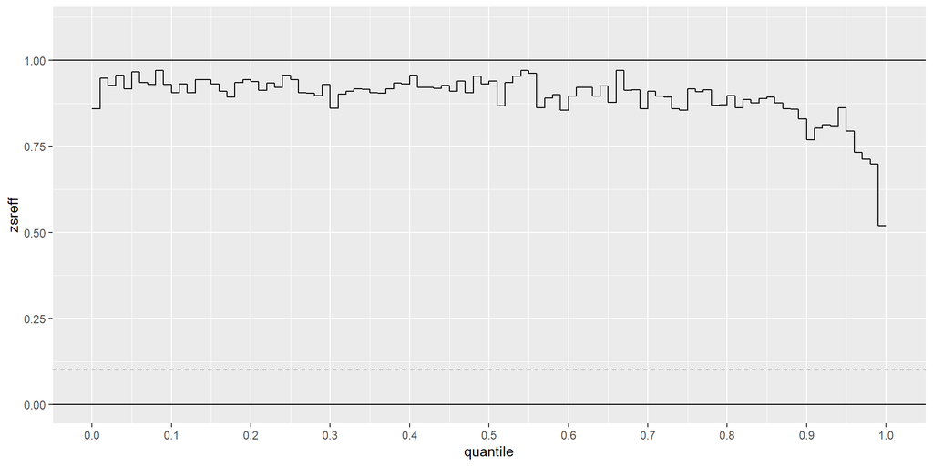

```r
plot_local_reff(samp = samp, par = 1, nalpha = 100)
```

The relative efficiency is mostly a bit below 1, but for the right tail of $x_1^2$ the relative efficiency drops. This likely due to only some iterations have high enough total energy to obtain draws from the high energy part of the tail.

Let’s check the relative efficiency of cumulative probabilities

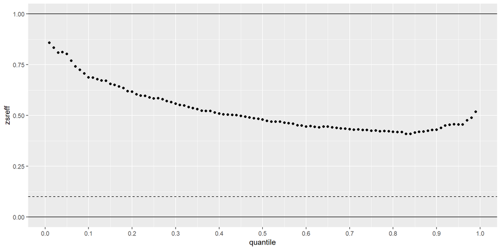

```r
plot_quantile_reff(samp = samp, par = 1, nalpha = 100)
```

We can see the correlation between `lp__` and magnitude of `x[1]` in the following plot.

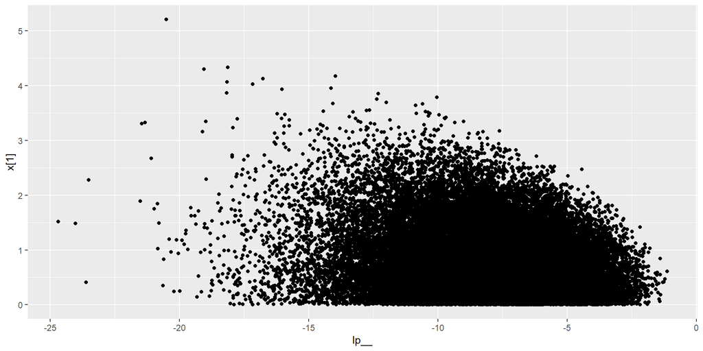

```r
samp <- as.array(fit_n)
qplot(
  as.vector(samp[, , "lp__"]),
  abs(as.vector(samp[, , "x[1]"]))
) +
  xlab('lp__') +
  ylab('x[1]')
```

Low `lp__` corresponds to high energy and more variation in `x[1]`, and high `lp__` corresponds to low energy and small variation in `x[1]`. Finally $\sum_{j=1}^J x_j^2$ is perfectly correlated with `lp__`.

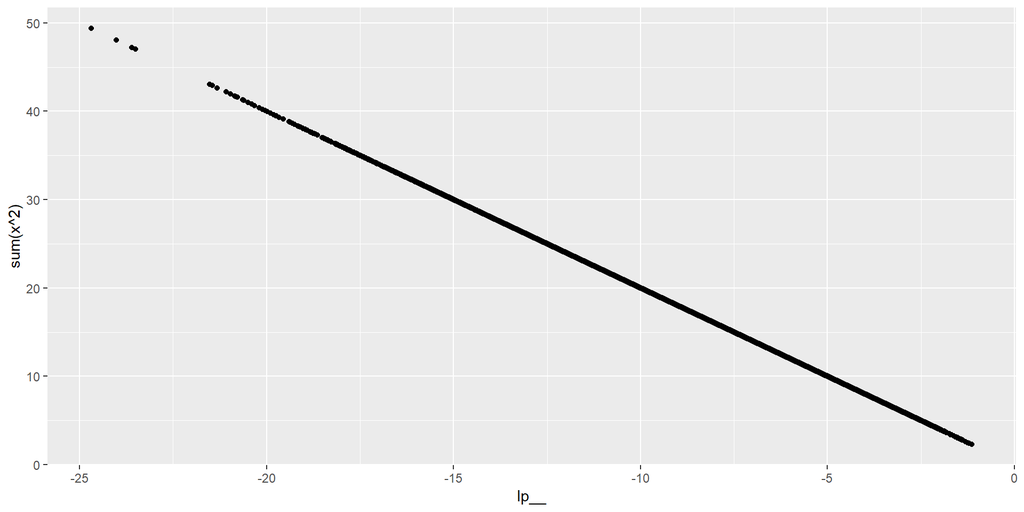

```r
qplot(
  as.vector(samp[, , "lp__"]),
  as.vector(apply(samp[, , 1:16]^2, 1:2, sum))
) +
  xlab('lp__') +
  ylab('sum(x^2)')
```

This shows that even if we get high relative efficiency estimates for parameters, it is important to look at the relative efficiency of `lp__` as it can indicate problems of sampling in tails, which would affect the accuracy of variance and tail quantile estimates.

# 5 Original Computing Environment

```r
makevars <- file.path(Sys.getenv("HOME"), ".R/Makevars")
if (file.exists(makevars)) {
  writeLines(readLines(makevars))
}
```

[output not shown]

```
Packages -----------------------------------------------------------------
```

```
 package      * version   date       source
 assertthat     0.2.0     2017-04-11 CRAN (R 3.5.0)
 BH             1.66.0-1  2018-02-13 CRAN (R 3.5.0)
 cli            1.0.0     2017-11-05 CRAN (R 3.5.0)
 colorspace     1.3-2     2016-12-14 CRAN (R 3.5.0)
 crayon         1.3.4     2017-09-16 CRAN (R 3.5.0)
 digest         0.6.15    2018-01-28 CRAN (R 3.5.0)
 fansi          0.2.3     2018-05-06 CRAN (R 3.5.1)
 ggplot2      * 3.0.0     2018-07-03 CRAN (R 3.5.1)
 glue           1.3.0     2018-07-17 CRAN (R 3.5.1)
 graphics     * 3.5.1     2018-07-02 local
 grDevices    * 3.5.1     2018-07-02 local
 grid           3.5.1     2018-07-02 local
 gridExtra    * 2.3       2017-09-09 CRAN (R 3.5.0)
 gtable         0.2.0     2016-02-26 CRAN (R 3.5.0)
 inline         0.3.15    2018-05-18 CRAN (R 3.5.1)
 labeling       0.3       2014-08-23 CRAN (R 3.5.0)
 lattice        0.20-35   2017-03-25 CRAN (R 3.5.1)
 lazyeval       0.2.1     2017-10-29 CRAN (R 3.5.0)
 magrittr       1.5       2014-11-22 CRAN (R 3.5.0)
 MASS           7.3-50    2018-04-30 CRAN (R 3.5.1)
 Matrix         1.2-14    2018-04-13 CRAN (R 3.5.1)
 methods      * 3.5.1     2018-07-02 local
 mgcv           1.8-24    2018-06-23 CRAN (R 3.5.1)
 munsell        0.5.0     2018-06-12 CRAN (R 3.5.1)
 nlme           3.1-137   2018-04-07 CRAN (R 3.5.1)
 pillar         1.3.0     2018-07-14 CRAN (R 3.5.0)
 plyr           1.8.4     2016-06-08 CRAN (R 3.5.0)
 R6             2.2.2     2017-06-17 CRAN (R 3.5.0)
 RColorBrewer   1.1-2     2014-12-07 CRAN (R 3.5.0)
 Rcpp           0.12.18   2018-07-23 CRAN (R 3.5.1)
 RcppEigen      0.3.3.4.0 2018-02-07 CRAN (R 3.5.0)
 reshape2       1.4.3     2017-12-11 CRAN (R 3.5.0)
 rlang          0.2.1     2018-05-30 CRAN (R 3.5.1)
 rstan        * 2.17.3    2018-01-20 CRAN (R 3.5.0)
 scales         1.0.0     2018-08-09 CRAN (R 3.5.1)
 StanHeaders  * 2.17.2    2018-01-20 CRAN (R 3.5.0)
 stats        * 3.5.1     2018-07-02 local
 stats4         3.5.1     2018-07-02 local
 stringi        1.2.4     2018-07-20 CRAN (R 3.5.1)
 stringr      * 1.3.1     2018-05-10 CRAN (R 3.5.1)
 tibble       * 1.4.2     2018-01-22 CRAN (R 3.5.0)
 tools          3.5.1     2018-07-02 local
 utf8           1.1.4     2018-05-24 CRAN (R 3.5.1)
 utils        * 3.5.1     2018-07-02 local
 viridisLite    0.3.0     2018-02-01 CRAN (R 3.5.0)
 withr          2.1.2     2018-04-26 Github (jimhester/withr@79d7b0d)
```